# 空間分析 作業六

電機四 B05901013 張景皓

4/21/2020

## 1-1.

```r
Temples.mazu.CF <- CF(id = 1, points = data.frame(Temples.mazu@coords[,1:2]));
```

```
##   id     CF.x    CF.y
## 1  1 194031.2 2616255
```

```r
target.temple <- subset(Temples.mazu, Temples.mazu$X_n == Temples.mazu.CF$CF.x & Temples.mazu$Y_n == Temples.mazu.CF$CF.y);

print(target.temple);
```

```
##              coordinates   ID COUNTYNAME TOWNNAME     FULLNAME   NAME 主祭神祇
## 5022 (194031.2, 2616255) 5022     雲林縣   大埤鄉 雲林縣大埤鄉 泰安宮     媽祖
##      祭祀圈層級      X_n     Y_n
## 5022     村落型 194031.2 2616255
```

## 1-2.

雲林縣斗六市。

```r
Temples.mazu.median <- median_centre(id = 1, points = data.frame(Temples.mazu@coords[,1:2]));
```

```
##   id median.x median.y
## 1  1 199825.6  2622245
```

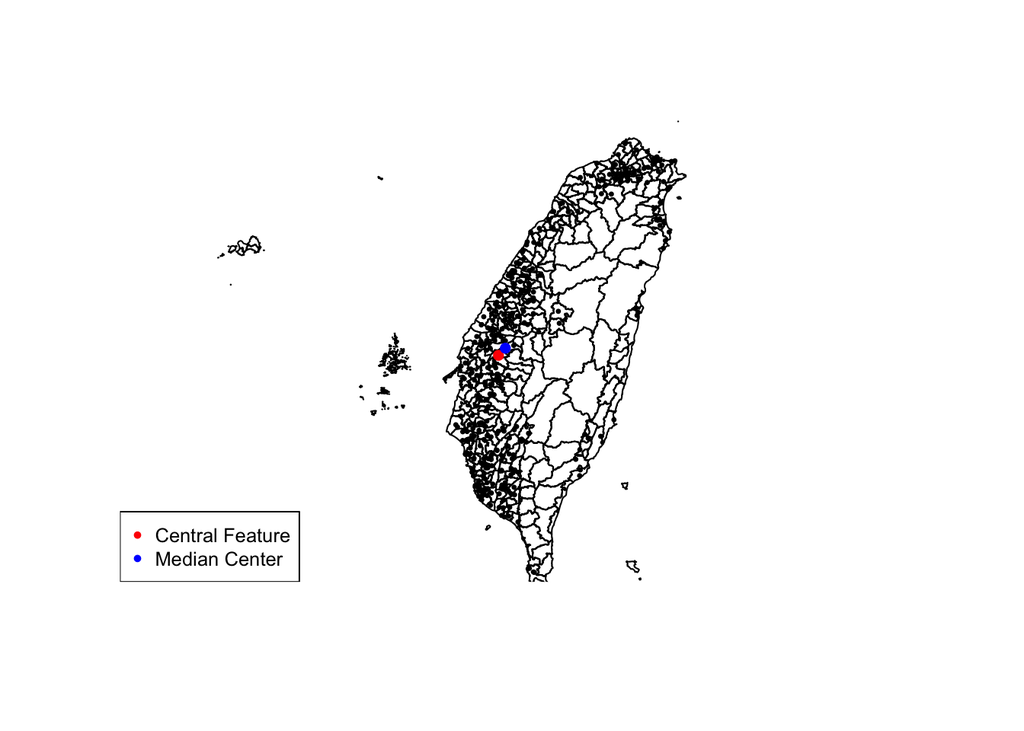

```r
plot(Popn_TWN, xlim = c(220000, 240000), ylim = c(2440000, 2800000));
plot(Temples.mazu, add = TRUE, pch = 20, cex = 0.5);
points(x = Temples.mazu.CF$CF.x, y = Temples.mazu.CF$CF.y, col = "red", cex = 1, pch = 16);
points(x = Temples.mazu.median$median.x, y = Temples.mazu.median$median.y, col = "blue", cex = 1, pch = 16);
legend("bottomleft", legend = c("Central Feature", "Median Center"), col = c("red", "blue"), pch = 20, cex = 0.8);
```

## 2-1.

```r
plot(Popn_TWN.county, xlim = c(220000, 240000), ylim = c(2450000, 2650000));
plot(Temples.south.mazu, add = TRUE, pch = 17, col = "pink", cex = 0.4);
plot(Temples.south.guanyin, add=TRUE, pch = 20, col = "sky blue", cex = 0.4);

Temples.south.mazu.centroid <- mean_centre(id = 1, weighted = FALSE, weights = NULL, points = Temples.south.mazu@coords);
```

```
##   id CENTRE.x CENTRE.y
## 1  1 187341.9  2537307
```

```r
Temples.south.mazu.sdd <- calc_sdd(id = 1, points = Temples.south.mazu@coords);
```

```
## $id
## [1] 1
##
## $calccentre
## [1] TRUE
##
## $weighted
## [1] FALSE
##
## $CENTRE.x
## [1] 187341.9
##
## $CENTRE.y
## [1] 2537307
##
## $SDD.radius
## [1] 38932.75
##
## $SDD.area
## [1] 4761897475
```

```r
Temples.south.mazu.sde <- calc_sde(id = 1, points = Temples.south.mazu@coords);
```

```
## $id
## [1] 1
##
## $CALCCENTRE
## [1] TRUE
##
## $weighted
## [1] FALSE
##
## $CENTRE.x
## [1] 187341.9
##
## $CENTRE.y
## [1] 2537307
##
## $Sigma.x
## [1] 18817.07
##
## $Sigma.y
## [1] 51743.95
##
## $Major
## [1] "SigmaY"
##
## $Minor
## [1] "SigmaX"
##
## $Theta
## [1] 172.1137
##
## $Eccentricity
## [1] 0.9315328
##
## $Area.sde
## [1] 3058872349
##
## $TanTheta
## [1] -0.1385176
##
## $SinTheta
## [1] 0.1372075
##
## $CosTheta
## [1] -0.9905423
##
## $SinThetaCosTheta
## [1] -0.1359098
##
## $Sin2Theta
## [1] 0.0188259
##
## $Cos2Theta
## [1] 0.9811741
##
## $ThetaCorr
## [1] 172.1137
```

```r
points(x = Temples.south.mazu.centroid$CENTRE.x, y = Temples.south.mazu.centroid$CENTRE.y, col = "red", cex = 1, pch = 17);
plot_sdd(plotnew = FALSE, plotcentre = FALSE, sdd.col = "red", sdd.lwd = 1, titletxt = "", plotpoints = FALSE);
plot_sde(plotnew = FALSE, plotcentre = FALSE, sde.col = "red", sdd.lwd = 1, titletxt = "", plotpoints = FALSE);

Temples.south.guanyin.centroid <- mean_centre(id = 1, weighted = FALSE, weights = NULL, points = Temples.south.guanyin@coords);
```

```
##   id CENTRE.x CENTRE.y
## 1  1 188873.5  2534496
```

```r
Temples.south.guanyin.sdd <- calc_sdd(id = 1, points = Temples.south.guanyin@coords);
```

```
## $id
## [1] 1
##
## $calccentre
## [1] TRUE
##
## $weighted
## [1] FALSE
##
## $CENTRE.x
## [1] 188873.5
##
## $CENTRE.y
## [1] 2534496
##
## $SDD.radius
## [1] 29140.77
##
## $SDD.area
## [1] 2667792457
```

```r
Temples.south.guanyin.sde <- calc_sde(id = 1, points = Temples.south.guanyin@coords);
```

```
## $id
## [1] 1
##
## $CALCCENTRE
## [1] TRUE
##
## $weighted
## [1] FALSE
##
## $CENTRE.x
## [1] 188873.5
##
## $CENTRE.y
## [1] 2534496
##
## $Sigma.x
## [1] 17588.73
##
## $Sigma.y
## [1] 37269.37
##
## $Major
## [1] "SigmaY"
##
## $Minor
## [1] "SigmaX"
##
## $Theta
## [1] 153.3438
##
## $Eccentricity
## [1] 0.8816332
##
## $Area.sde
## [1] 2059379646
##
## $TanTheta
## [1] -0.5019909
##
## $SinTheta
## [1] 0.4486365
##
## $CosTheta
## [1] -0.8937143
##
## $SinThetaCosTheta
## [1] -0.4009528
##
## $Sin2Theta
## [1] 0.2012747
##
## $Cos2Theta
## [1] 0.7987253
##
## $ThetaCorr
## [1] 153.3438
```

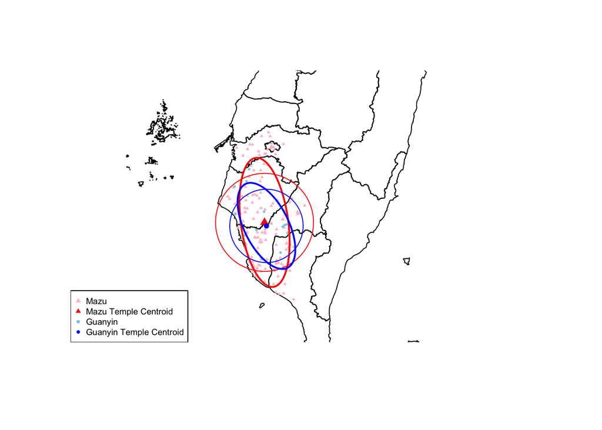

```r
points(x = Temples.south.guanyin.centroid$CENTRE.x, y = Temples.south.guanyin.centroid$CENTRE.y, col = "blue", cex = 1, pch = 20);
plot_sdd(plotnew = FALSE, plotcentre = FALSE, sdd.col = "blue", sdd.lwd = 1, titletxt = "", plotpoints = FALSE);
plot_sde(plotnew = FALSE, plotcentre = FALSE, sde.col = "blue", sdd.lwd = 1, titletxt = "", plotpoints = FALSE);

legend("bottomleft", legend = c("Mazu", "Mazu Temple Centroid", "Guanyin", "Guanyin Temple Centroid"), col = c("pink", "red", "sky blue", "blue"), pch = c(17, 17, 20, 20), cex = 0.6);
```

## 2-2.

```r
bb <- bbox(Temples.south);
grd <- GridTopology(cellcentre.offset = bb[ ,1], cellsize = c(20000, 20000), cells.dim = ceiling((bb[,2] - bb[,1])/20000 + 0.5));
grd <- as.SpatialPolygons.GridTopology(grd, Temples@proj4string);

Mazu.count <- poly.counts(Temples.south.mazu, grd);
grd.mazu <- SpatialPolygonsDataFrame(grd, data = data.frame(Mazu.count), match.ID = TRUE);
Mazu.df <- sum(grd.mazu$Mazu.count) - 1;
Mazu.mean <- mean(grd.mazu$Mazu.count);
Mazu.variance <- var(grd.mazu$Mazu.count);
Mazu.vmr <- Mazu.variance / Mazu.mean;
Mazu.se <- sqrt(2/Mazu.df);
Mazu.t <- (Mazu.vmr - 1) / Mazu.se;

Guanyin.count <- poly.counts(Temples.south.guanyin, grd);
grd.guanyin <- SpatialPolygonsDataFrame(grd, data = data.frame(Guanyin.count), match.ID = TRUE);
Guanyin.df <- sum(grd.guanyin$Guanyin.count) - 1;
Guanyin.mean <- mean(grd.guanyin$Guanyin.count);
Guanyin.variance <- var(grd.guanyin$Guanyin.count);
Guanyin.vmr <- Guanyin.variance / Guanyin.mean;
Guanyin.se <- sqrt(2/Guanyin.df);
Guanyin.t <- (Guanyin.vmr - 1) / Guanyin.se;
```

### VMR test of Mazu temples

$H_0:\sigma^2=\lambda$  
$H_1:\sigma^2\neq\lambda$  
The test is carried out at 95% confidence level.

### VMR test of Guanyin temples

$H_0:\sigma^2=\lambda$  
$H_1:\sigma^2\neq\lambda$  
The test is carried out at 95% confidence level.

$\mathrm{VMR} = \frac{\sigma^2}{\lambda} = 0.9128 / 0.4 \approx 2.2821$  
$\mathrm{df} = k - 1 = 15$  
$s_\mathrm{vmr}=\sqrt{\frac{2}{15}}\approx 0.3652$  
$t = \frac{\mathrm{vmr}-1}{s_\mathrm{vmr}}\approx 3.511$

The critical values obtained from the t-distribution for $\alpha=0.025$ (two-tailed test), and $\mathrm{df}=15$ are $\pm2.13145$. Therefore, the test fails and $H_0$ is rejected. Alternatively, $H_1$ which states the point pattern is not random is accepted. When the statistical testing is redone with $H_1:\sigma^2>\lambda$ (pattern is clustered), the critical value from the t-distribution for $\alpha=0.05$ (one-tail test) is 1.75305. The test also fails and $H_0$ is rejected, and $H_1$ which states that point pattern is clustered is accepted.

### Conclusion:

Both the VMR of Mazu temples and Guanyin Temples are greater than 1, indicating they are both over-dispersed. The results of the VMR-tests show Mazu temples are more clusteringly distributed over the Southern Taiwan region, where Guanyin temples approximate random distribution comparatively.

## 2-3.

```r
bb.new <- bbox(Temples.south.mazu);
grd20 <- GridTopology(cellcentre.offset = bb.new[ ,1], cellsize = c(20000, 20000), cells.dim = ceiling((bb.new[,2] - bb.new[,1])/20000 + 0.5));
grd20 <- as.SpatialPolygons.GridTopology(grd20, Temples@proj4string);
Mazu.count20 <- poly.counts(Temples.south.mazu, grd20);
grd20.new <- SpatialPolygonsDataFrame(grd20, data = data.frame(Mazu.count20), match.ID = TRUE);

grd20.df <- sum(grd20.new$Mazu.count20) - 1;
grd20.mean <- mean(grd20.new$Mazu.count20);
grd20.variance <- var(grd20.new$Mazu.count20);
grd20.vmr <- grd20.variance / grd20.mean;
grd20.se <- sqrt(2/grd20.df);
grd20.t <- (grd20.vmr - 1) / grd20.se;

grd50 <- GridTopology(cellcentre.offset = bb.new[ ,1], cellsize = c(50000, 50000), cells.dim = ceiling((bb.new[,2] - bb.new[,1])/50000 + 0.5));
grd50 <- as.SpatialPolygons.GridTopology(grd50, Temples@proj4string);
Mazu.count50 <- poly.counts(Temples.south.mazu, grd50);
grd50.new <- SpatialPolygonsDataFrame(grd50, data = data.frame(Mazu.count50), match.ID = TRUE);

grd50.df <- sum(grd50.new$Mazu.count50) - 1;
grd50.mean <- mean(grd50.new$Mazu.count50);
grd50.variance <- var(grd50.new$Mazu.count50);
grd50.vmr <- grd50.variance / grd50.mean;
grd50.se <- sqrt(2/grd50.df);
grd50.t <- (grd50.vmr - 1) / grd50.se;
```

### VMR test of Mazu temples in 20(km) X 20(km) grid

$H_0:\sigma^2=\lambda$  
$H_1:\sigma^2\neq\lambda$  
The test is carried out at 95% confidence level.

### VMR test of Mazu temples in 50(km) X 50(km) grid

$H_0:\sigma^2=\lambda$  
$H_1:\sigma^2\neq\lambda$  
The test is carried out at 95% confidence level.

### Conclusion:

When different cellsize of gridTopology() are implemented, it can result in drastically different means and variances of the same analysis set. In the case of Mazu temples of Southern Taiwan region, applying the $20(\mathrm{km})\times20(\mathrm{km})$ grid brings about variance-mean ratio (VMR) of 7 (uniformly clustered), whereas applying the $50(\mathrm{km})\times50(\mathrm{km})$ grid brings about more than 2 times of the previous VMR (densely clustered), even though the distribution of the Mazu temples has never changed in reality.

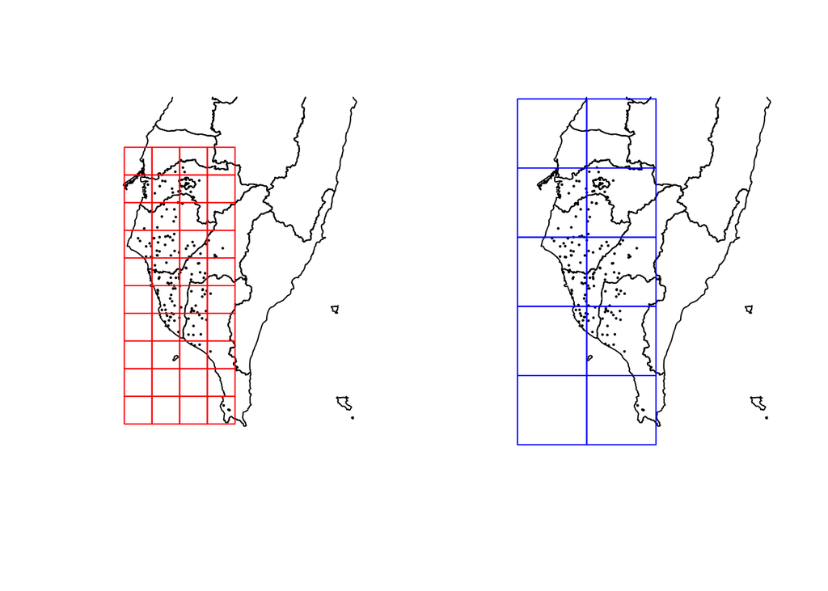

```r
par(mfrow = c(1, 2));
plot(Popn_TWN.county, xlim = c(210000, 240000), ylim = c(2400000, 2650000));
plot(Temples.south.mazu, add = TRUE, pch = 16, cex = 0.3);
plot(grd20, add = TRUE, border = "red");

plot(Popn_TWN.county, xlim = c(210000, 240000), ylim = c(2400000, 2650000));
plot(Temples.south.mazu, add = TRUE, pch = 16, cex = 0.3);
plot(grd50, add = TRUE, border = "blue")
```